## 2. Hierarchical Clustering

```r
# Choose the method you believe is more appropriate between these:"ward.D", "ward.D2", "single", "complete", "average" (= UPGMA), "mcquitty" (= WPGMA), "median" (= WPGMC) or "centroid" (= UPGMC).
# Se info in: https://uc-r.github.io/hc_clustering#algorithms

# This is the formula for calculating the dissimilarity matrix used at the start of the script. I have pasted it here again for convenience, but I have excluded from the dataset the columns where I stored the patient ID (1) and pam results (50)

# gower.dist <- daisy(data[,-c(1, 50)], stand = TRUE, metric = c("gower"))
#summary(gower.dist)

# we will use the same dissimilarity matrix calculated above
set.seed(658)
cluster2 <- hclust(gower.dist, method="complete")

# Cut the dendogram data in the k-number of groups and calculate a Dunn's Index to see the goodness of the cluster
# Despite the ideal k number was 3, I have written a loop to see whether the Dunn's Index increases with different k values, because it was quite low at k=3

for(i in 2:10){
  sub_grp <- cutree(cluster2, k = i)

  # Dunn's Index: the ratio between the minimum inter-cluster distances to the maximum intra-cluster diameter. The diameter of a cluster is the distance between its two furthermost points. In order to have well separated and compact clusters you should aim for a higher Dunn's index. It has a value from 0 to infinite.

  print(paste0("If k= ", i, " then Dunn's Index = ", round(dunn(distance = as.matrix(gower.dist), clusters= sub_grp),2)))
}
```

```
## [1] "If k= 2 then Dunn's Index = 0.08"
## [1] "If k= 3 then Dunn's Index = 0.09"
## [1] "If k= 4 then Dunn's Index = 0.09"
## [1] "If k= 5 then Dunn's Index = 0.09"
## [1] "If k= 6 then Dunn's Index = 0.09"
## [1] "If k= 7 then Dunn's Index = 0.1"
## [1] "If k= 8 then Dunn's Index = 0.1"
## [1] "If k= 9 then Dunn's Index = 0.1"
## [1] "If k= 10 then Dunn's Index = 0.1"
```

```r
# Dunn's Index do not vary much changing k-values. Also, I have tried to run the analyzes again with all the other algorithms and the maximum Dunn'Index value obatined is anyway 0.4 with k=2

# Print height results. If you wish to see other results frrom the cluster just call the 'cluster$' list and select the voice you need
# cluster2$height

# I will keep the original k value calculated with the Sillouhette method
sub_grp <- cutree(cluster2, k = k)
table(sub_grp)
```

```
## sub_grp
##   1   2   3
## 547 104   7
```

```r
# save cluster number in the main dataset
data <- cbind(data,sub_grp)
colnames(data)[ncol(data)] <- 'Hclust'

# Check averages per each group
x1 <- round(aggregate(data[,c('DELTAPASI.', 'Edad')], list(data$Hclust), mean),2)
x1[order(x1$DELTAPASI.),]
```

```
##   Group.1 DELTAPASI.  Edad
## 3       3      -0.69 55.57
## 2       2      -0.46 47.14
## 1       1      -0.35 49.19
```

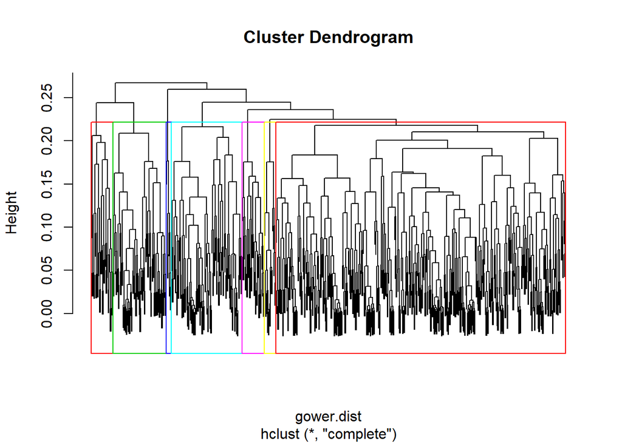

```r
# Dendogram 1: dendogram with labels and squares around the clusters - It is very complex, because you have a lot of data. Consider subsetting your dataset and re-calculating Gower Distance on a random subsample
plot(cluster2, cex = 0.6, labels=FALSE)
rect.hclust(cluster2, k = 7, border = 2:7)
abline(h = 7, col = 'red')
```

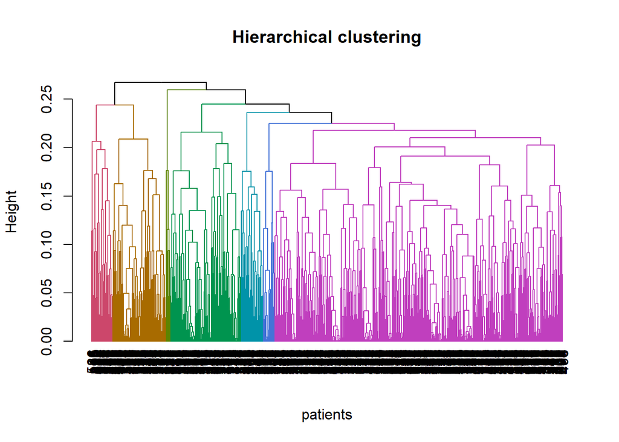

```r
# Dendogram 2: coloured branches - easier to be analysed
avg_dend_obj <- as.dendrogram(cluster2)
avg_col_dend <- color_branches(avg_dend_obj, h = 0.22)
plot(avg_col_dend,
     main= "Hierarchical clustering",
     xlab="patients",
     ylab= "Height")
```

```r
# save in pdf
pdf(file= './Hierarchical_clustering.pdf', width= 9, height= 9)
plot(avg_col_dend,
     main= "Hierarchical clustering",
     xlab="patients",
     ylab= "Height")
dev.off()
```

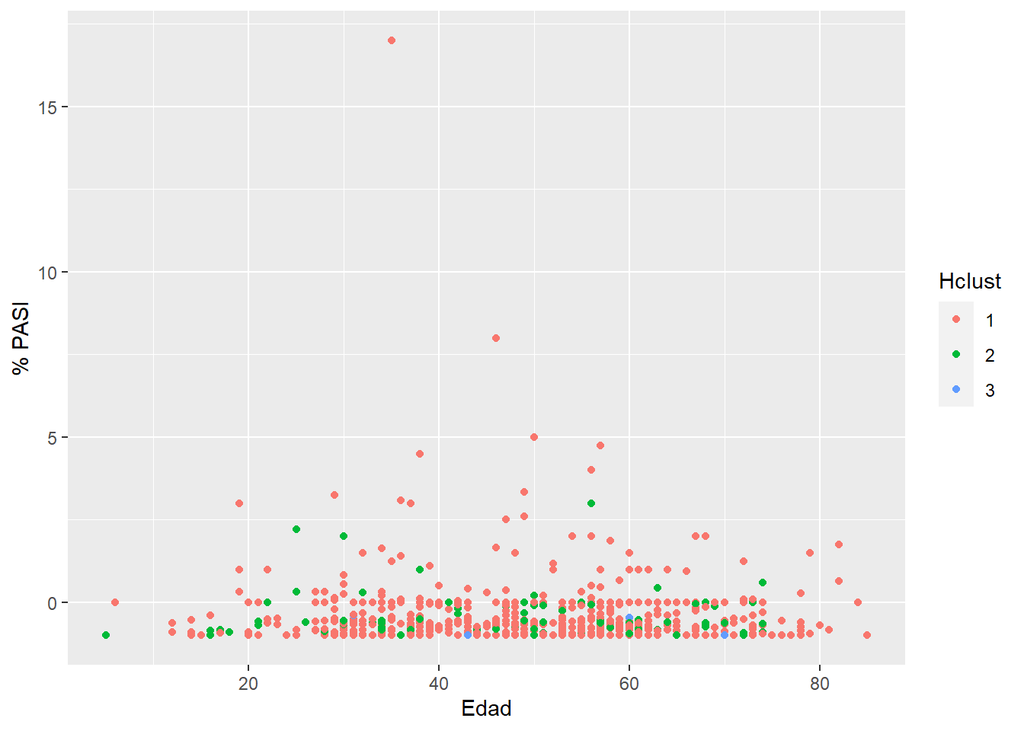

```r
# See whether there is any linear relationship between the age of the patients and the %PASI and whether that varies between groups
ggplot(data, aes(x= data$Edad, y = data$DELTAPASI., color = factor(Hclust))) +
  geom_point() +
  labs(colour = factor("Hclust"),
       x = "Edad",
       y = "% PASI")
```

```r
# There is no correlation between age and % PASI
```

### CONCLUSIONS:

Overall, I believe the PAM analysis as well as the k-means do not suit your type of dataset, since they are robust when considering continuous data. The Hierarchical Clustering analysis evidenced weak Dunn’s indices, suggesting that the clustering is not consistent. Considering that the maximum average Gower Distance calculated is of 0.27, I believe the overall result is that there isn’t much difference between clinical cases independently of their age, genre, status or the type of treatment they have received. Perhaps play around the script a little bit, excluding some more variables from the analysis in the ‘Dataset preparation’ section and even reducing the dataset to a subsample of patients. (Maybe considering females and males separately and running the analysis in two different groups?)